# project3

```python
import pandas as pd

# read and peek at the data
data = pd.read_csv("mirror/08_gap-every-five-years.tsv", sep='\t')
data.head()
```

|  | country | continent | year | lifeExp | pop | gdpPercap |
| --- | --- | --- | --- | --- | --- | --- |
| 0 | Afghanistan | Asia | 1952 | 28.801 | 8425333 | 779.445314 |
| 1 | Afghanistan | Asia | 1957 | 30.332 | 9240934 | 820.853030 |
| 2 | Afghanistan | Asia | 1962 | 31.997 | 10267083 | 853.100710 |
| 3 | Afghanistan | Asia | 1967 | 34.020 | 11537966 | 836.197138 |
| 4 | Afghanistan | Asia | 1972 | 36.088 | 13079460 | 739.981106 |

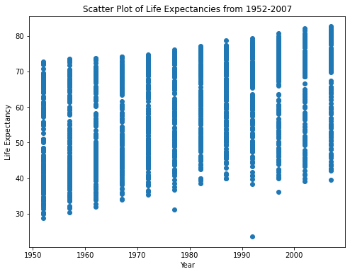

```python
import matplotlib.pyplot as plt

# create a scatter plot of life expectancy vs time
fig, ax = plt.subplots(figsize=[8,6])
ax.scatter(data.year, data.lifeExp)
ax.set_xlabel('Year')
ax.set_ylabel('Life Expectancy')
ax.set_title('Scatter Plot of Life Expectancies from 1952-2007')
plt.show()
```

From the above scatter plot, it appears that life expectancy is increasing across time. The trend appears linear.

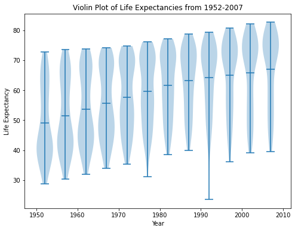

```python
# make a list of life expectancy grouped by year
lifeExpPerYear = data.groupby('year')['lifeExp'].apply(list)

# create a violin plot of life expectancy vs time
fig, ax = plt.subplots(figsize=[8,6])
ax.violinplot(lifeExpPerYear, data.year.unique(), widths=4, showmeans=True)
ax.set_xlabel("Year")
ax.set_ylabel("Life Expectancy")
ax.set_title("Violin Plot of Life Expectancies from 1952-2007")
plt.show()
```

For 1952 and 1957, the distribution of life expectancy across countries is skewed toward older ages. In 1962, 1967, and 1972, the distribution appears bimodal around its center as the distribution around the higher mode grows bigger. From 1977 and onward, the distribution of life expectancy has a signficant skew toward younger ages. I predict that a linear regression model of life expectancy vs year will lead me to reject the null hypothesis of no relationship because from the violin plot I can clearly see the mean life expectancy increasing across time. I predict that a violin plot of residuals from this linear model would be centered at 0 and have the same overall shape as the life expectancy vs year violin plot. According to the assumptions of the linear regression model, the residual violin plot should look like what I predict because the best predictor for each year is the mean, and thus the input distribution will show in the residues distribution.

```python
import numpy as np
from sklearn.linear_model import LinearRegression

# make a linear regression model of life expectancy vs year
year = np.array(data.year).reshape((-1,1))
life = np.array(data.lifeExp)
reg = LinearRegression().fit(year, life)

# print R^2, slope, and y-intercept
r_sq = reg.score(year, life)
print('coefficient of determination:', r_sq)

m = reg.coef_
print('slope:', m)

b = reg.intercept_
print('intercept:', b)
```

```
coefficient of determination: 0.18975713852188814
slope: [0.32590383]
intercept: -585.6521874415448
```

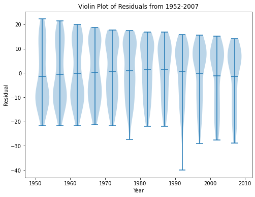

```python
# get the predicted life expectancy for each year
data['predictedLifeExp'] = reg.predict(year)
# residual = actual - predicted
data['residual'] = data['lifeExp'] - data['predictedLifeExp']

# make a list of residuals grouped by year
residualPerYear = data.groupby('year')['residual'].apply(list)

# create a violin plot of residuals vs time
fig, ax = plt.subplots(figsize=[8,6])
ax.violinplot(residualPerYear, data.year.unique(), widths=4, showmeans=True)
ax.set_xlabel("Year")
ax.set_ylabel("Residual")
ax.set_title("Violin Plot of Residuals from 1952-2007")
plt.show()
```

The violin plot does match my expectations. The residuals are generally centered at 0 and have the same overall shape as the life expectancy vs year violin plot.

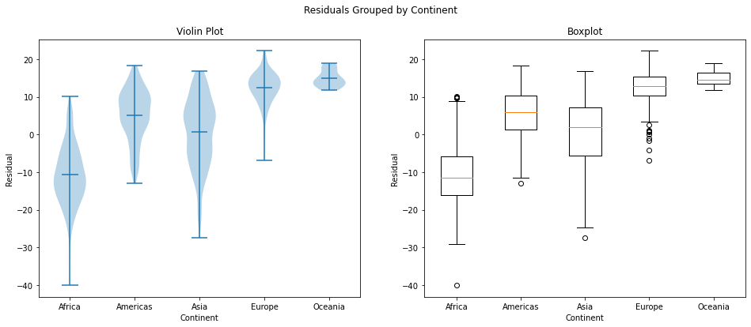

```python
# array of 0-4
x_int = [*range(len(continents))]
# list of continents, sorted alphabetically
continents = sorted(data.continent.unique())
# list of residuals grouped by continent
residualPerContinent = data.groupby('continent', sort=True)['residual'].apply(list)

fig, (ax1, ax2) = plt.subplots(nrows=1, ncols=2, figsize=[16,6])
fig.suptitle('Residuals Grouped by Continent')

# create a violin plot of residuals vs continent
ax1.violinplot(residualPerContinent, x_int, showmeans=True)
ax1.set_xlabel("Continent")
ax1.set_ylabel("Residual")
ax1.set_title("Violin Plot")
ax1.set_xticks(x_int, continents)

# create a boxplot of residuals vs continent
ax2.boxplot(residualPerContinent, labels=continents)
ax2.set_xlabel("Continent")
ax2.set_ylabel("Residual")
ax2.set_title("Boxplot")

plt.show()
```

There is a dependence between the model residual and continent. This would suggest that a regression model analyzing life expectancy across time should take into account the continent.

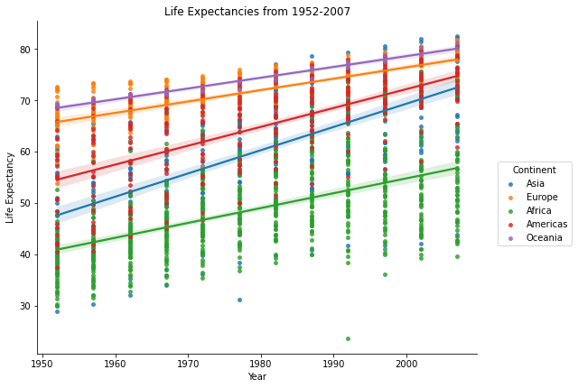

```python
import seaborn as sns

# create a scatter plot with a regression line for each continent
fg = sns.lmplot(x='year', y='lifeExp', hue='continent', data=data, scatter_kws={"s": 15}, legend=False)
fg.set(xlabel='Year', ylabel='Life Expectancy', title='Life Expectancies from 1952-2007')
fg.fig.set_size_inches(8,6)
fg.fig.legend(bbox_to_anchor=(1,0.5), loc='center left', frameon=True, title='Continent')
plt.show()
```

The regression model should include an interaction term for continent and year. Based on this plot, we can see that the slope of the linear regression lines between continents have different slopes, which suggests that an interaction effect might be present.

```python
from sklearn.preprocessing import OneHotEncoder

# get continent array from dataframe and reshape
continents = np.array(data.continent).reshape((-1,1))

enc = OneHotEncoder()
# auto create categories for one-hot encode
enc.fit(continents)
# one-hot encode the continent array
inv_encoded = enc.transform(continents).toarray().T

# add one-hot encoded continents to the main dataframe
categories = enc.categories_[0]
for i in range(len(categories)):
    data[categories[i]] = inv_encoded[i]

# normalize year from 0 to 1
data['normYear'] = (data['year'] - data['year'].min()) / (data['year'].max() - data['year'].min())
data
```

|  | country | continent | year | lifeExp | pop | gdpPercap | predictedLifeExp | residual | Africa | Americas | Asia | Europe | Oceania | normYear |
| --- | --- | --- | --- | --- | --- | --- | --- | --- | --- | --- | --- | --- | --- | --- |
| 0 | Afghanistan | Asia | 1952 | 28.801 | 8425333 | 779.445314 | 50.512084 | -21.711084 | 0.0 | 0.0 | 1.0 | 0.0 | 0.0 | 0.000000 |
| 1 | Afghanistan | Asia | 1957 | 30.332 | 9240934 | 820.853030 | 52.141603 | -21.809603 | 0.0 | 0.0 | 1.0 | 0.0 | 0.0 | 0.090909 |
| 2 | Afghanistan | Asia | 1962 | 31.997 | 10267083 | 853.100710 | 53.771122 | -21.774122 | 0.0 | 0.0 | 1.0 | 0.0 | 0.0 | 0.181818 |
| 3 | Afghanistan | Asia | 1967 | 34.020 | 11537966 | 836.197138 | 55.400642 | -21.380642 | 0.0 | 0.0 | 1.0 | 0.0 | 0.0 | 0.272727 |
| 4 | Afghanistan | Asia | 1972 | 36.088 | 13079460 | 739.981106 | 57.030161 | -20.942161 | 0.0 | 0.0 | 1.0 | 0.0 | 0.0 | 0.363636 |
| ... | ... | ... | ... | ... | ... | ... | ... | ... | ... | ... | ... | ... | ... | ... |
| 1699 | Zimbabwe | Africa | 1987 | 62.351 | 9216418 | 706.157306 | 61.918718 | 0.432282 | 1.0 | 0.0 | 0.0 | 0.0 | 0.0 | 0.636364 |
| 1700 | Zimbabwe | Africa | 1992 | 60.377 | 10704340 | 693.420786 | 63.548237 | -3.171237 | 1.0 | 0.0 | 0.0 | 0.0 | 0.0 | 0.727273 |
| 1701 | Zimbabwe | Africa | 1997 | 46.809 | 11404948 | 792.449960 | 65.177756 | -18.368756 | 1.0 | 0.0 | 0.0 | 0.0 | 0.0 | 0.818182 |
| 1702 | Zimbabwe | Africa | 2002 | 39.989 | 11926563 | 672.038623 | 66.807275 | -26.818275 | 1.0 | 0.0 | 0.0 | 0.0 | 0.0 | 0.909091 |
| 1703 | Zimbabwe | Africa | 2007 | 43.487 | 12311143 | 469.709298 | 68.436795 | -24.949795 | 1.0 | 0.0 | 0.0 | 0.0 | 0.0 | 1.000000 |

1704 rows × 14 columns

```python
from sklearn.preprocessing import PolynomialFeatures

# append normalized year to OHE continent
normYear_encCont = np.vstack((np.array(data.normYear), np.array(data[['Africa','Americas','Asia','Europe','Oceania']].T))).T

# create polynomial interaction (function?) with exponent degree 2. 6+6C2 = 21
interaction = PolynomialFeatures(degree=2, include_bias=False, interaction_only=True)
# get the new term names
polyNames = interaction.fit(normYear_encCont).get_feature_names_out(['normYear','Africa','Americas','Asia','Europe','Oceania'])
# actually multiply out the terms
poly = interaction.fit_transform(normYear_encCont)
life = np.array(data.lifeExp)
# only use the normYear*continent terms, no continent*continent
poly_df = pd.DataFrame(poly[:,range(0,11)], columns=polyNames[range(0,11)])
life_df = pd.Series(life, name='lifeExp')

# make a linear regression model of life expectancy (w interaction terms) vs year
model = LinearRegression().fit(poly_df, life_df)

# print R^2, slope, and y-intercept
r_sq = model.score(poly_df, life_df)
print('coefficient of determination:', r_sq)

b = model.intercept_
print('intercept:', b)

coefs = model.coef_
coef_df = pd.DataFrame(coefs.reshape(1,-1), columns=polyNames[range(0,11)])
print('coefficients:')
display(coef_df)
```

```
coefficient of determination: 0.6919730411420963
intercept: -444964186593590.0
coefficients:
```

|  | normYear | Africa | Americas | Asia | Europe | Oceania | normYear Africa | normYear Americas | normYear Asia | normYear Europe | normYear Oceania |
| --- | --- | --- | --- | --- | --- | --- | --- | --- | --- | --- | --- |
| 0 | -2.300116e+14 | 4.449642e+14 | 4.449642e+14 | 4.449642e+14 | 4.449642e+14 | 4.449642e+14 | 2.300116e+14 | 2.300116e+14 | 2.300116e+14 | 2.300116e+14 | 2.300116e+14 |

```python
import statsmodels.api as sm

# add b (y-intercept) to model
poly_df = sm.add_constant(poly_df)

# print summary
mod = sm.OLS(life_df, poly_df)
res = mod.fit()
res.summary()
```

OLS Regression Results

| Dep. Variable: | lifeExp | R-squared: | 0.693 |
| --- | --- | --- | --- |
| Model: | OLS | Adj. R-squared: | 0.691 |
| Method: | Least Squares | F-statistic: | 424.3 |
| Date: | Fri, 02 Dec 2022 | Prob (F-statistic): | 0.00 |
| Time: | 02:54:41 | Log-Likelihood: | -5771.9 |
| No. Observations: | 1704 | AIC: | 1.156e+04 |
| Df Residuals: | 1694 | BIC: | 1.162e+04 |
| Df Model: | 9 |  |  |
| Covariance Type: | nonrobust |  |  |

|  | coef | std err | t | P>\|t\| | [0.025 | 0.975] |
| --- | --- | --- | --- | --- | --- | --- |
| const | 46.2333 | 0.513 | 90.155 | 0.000 | 45.227 | 47.239 |
| normYear | 14.1396 | 0.869 | 16.277 | 0.000 | 12.436 | 15.843 |
| Africa | -5.3300 | 0.677 | -7.877 | 0.000 | -6.657 | -4.003 |
| Americas | 8.3150 | 0.817 | 10.171 | 0.000 | 6.712 | 9.918 |
| Asia | 1.3707 | 0.755 | 1.815 | 0.070 | -0.110 | 2.852 |
| Europe | 19.5672 | 0.775 | 25.245 | 0.000 | 18.047 | 21.087 |
| Oceania | 22.3104 | 2.309 | 9.664 | 0.000 | 17.782 | 26.838 |
| normYear Africa | 1.7845 | 1.146 | 1.557 | 0.120 | -0.464 | 4.033 |
| normYear Americas | 6.0812 | 1.385 | 4.391 | 0.000 | 3.365 | 8.797 |
| normYear Asia | 10.7821 | 1.279 | 8.430 | 0.000 | 8.274 | 13.291 |
| normYear Europe | -1.9334 | 1.313 | -1.473 | 0.141 | -4.509 | 0.642 |
| normYear Oceania | -2.5747 | 3.911 | -0.658 | 0.510 | -10.245 | 5.096 |

| Omnibus: | 27.121 | Durbin-Watson: | 0.242 |
| --- | --- | --- | --- |
| Prob(Omnibus): | 0.000 | Jarque-Bera (JB): | 44.106 |
| Skew: | -0.121 | Prob(JB): | 2.65e-10 |
| Kurtosis: | 3.750 | Cond. No. | 3.74e+15 |

Notes:  
[1] Standard Errors assume that the covariance matrix of the errors is correctly specified.  
[2] The smallest eigenvalue is 1.97e-28. This might indicate that there are  
strong multicollinearity problems or that the design matrix is singular.

Most of the parameters in the model are statstically signficant. The Asia, normYear*Africa, normYear*Europe, and normYear*Oceania parameters in the model are not statistically signifcant from zero since their p-values are greater than 0.05.

```python
one_year = 1 / (data['year'].max() - data['year'].min())
# Africa
print(model.predict([[one_year,1,0,0,0,0,one_year,0,0,0,0]]) - model.predict([[0,1,0,0,0,0,0,0,0,0,0]]))
# Americas
print(model.predict([[one_year,0,1,0,0,0,0,one_year,0,0,0]]) - model.predict([[0,0,1,0,0,0,0,0,0,0,0]]))
# Asia
print(model.predict([[one_year,0,0,1,0,0,0,0,one_year,0,0]]) - model.predict([[0,0,0,1,0,0,0,0,0,0,0]]))
# Europe
print(model.predict([[one_year,0,0,0,1,0,0,0,0,one_year,0]]) - model.predict([[0,0,0,0,1,0,0,0,0,0,0]]))
# Oceania
print(model.predict([[one_year,0,0,0,0,1,0,0,0,0,one_year]]) - model.predict([[0,0,0,0,0,1,0,0,0,0,0]]))
```

```
[0.25]
[0.375]
[0.4375]
[0.1875]
[0.1875]
```

For Africa, the average life expectancy increases by 0.25 years (~3 months) every year. For the Americas, the average life expectancy increases by 0.375 years (~4.5 months) every year. For Asia, the average life expectancy increases by 0.4375 years (~5.25 months) every year. For Europe, the average life expectancy increases by 0.1875 years (~2.25 months) every year. For Oceania, the average life expectancy increases by 0.1875 years (~2.25 months) every year.

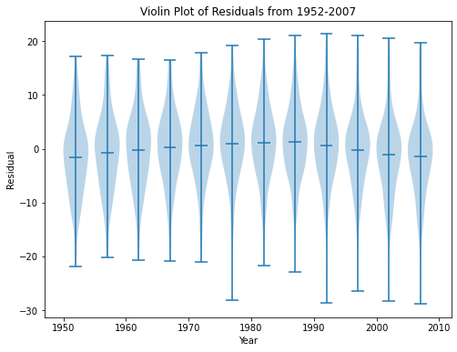

```python
# get the predicted life expectancy for each year
data['predictedLifeExp_int'] = model.predict(poly_df.loc[:,poly_df.columns != 'const'])
# residual = actual - predicted
data['residual_int'] = data['lifeExp'] - data['predictedLifeExp_int']

# make a list of residuals grouped by year
residualPerYear_int = data.groupby('year')['residual_int'].apply(list)

# create a violin plot of residuals vs time
fig, ax = plt.subplots(figsize=[8,6])
ax.violinplot(residualPerYear_int, data.year.unique(), widths=4, showmeans=True)
ax.set_xlabel("Year")
ax.set_ylabel("Residual")
ax.set_title("Violin Plot of Residuals from 1952-2007")
plt.show()
```

```python
from sklearn.datasets import load_iris

iris = load_iris()
iris_df = pd.DataFrame(data = np.c_[iris['data'], iris['target']], columns = iris['feature_names'] + ['target'])
iris_df
```

|  | sepal length (cm) | sepal width (cm) | petal length (cm) | petal width (cm) | target |
| --- | --- | --- | --- | --- | --- |
| 0 | 5.1 | 3.5 | 1.4 | 0.2 | 0.0 |
| 1 | 4.9 | 3.0 | 1.4 | 0.2 | 0.0 |
| 2 | 4.7 | 3.2 | 1.3 | 0.2 | 0.0 |
| 3 | 4.6 | 3.1 | 1.5 | 0.2 | 0.0 |
| 4 | 5.0 | 3.6 | 1.4 | 0.2 | 0.0 |
| ... | ... | ... | ... | ... | ... |
| 145 | 6.7 | 3.0 | 5.2 | 2.3 | 2.0 |
| 146 | 6.3 | 2.5 | 5.0 | 1.9 | 2.0 |
| 147 | 6.5 | 3.0 | 5.2 | 2.0 | 2.0 |
| 148 | 6.2 | 3.4 | 5.4 | 2.3 | 2.0 |
| 149 | 5.9 | 3.0 | 5.1 | 1.8 | 2.0 |

150 rows × 5 columns

I chose a dataset about the iris flower. We are trying to classify which type of iris it is based on the sepal length and width, and the petal length and width. The types of irises are: iris-setosa (0), iris-versicolour (1), or iris-virginica (2). The predictors in this dataset are already all numeric. The target class has also been converted from categorical to numeric. The performnace metric that I will be using is accuracy.

```python
from sklearn.model_selection import cross_val_score
from sklearn.discriminant_analysis import LinearDiscriminantAnalysis

X = iris_df[['sepal length (cm)', 'sepal width (cm)', 'petal length (cm)', 'petal width (cm)']]
y = iris_df['target']

lda = LinearDiscriminantAnalysis()
lda.fit(X, y)
scores = cross_val_score(lda, X, y, cv=10)
print("%0.2f accuracy with a standard deviation of %0.2f" % (scores.mean(), scores.std()))
```

```
0.98 accuracy with a standard deviation of 0.04
```

The first algorithm I chose is Linear Discriminant Analysis (LDA). This model does not have hyperparameters.

```python
from sklearn.model_selection import GridSearchCV
from sklearn import svm

parameters = {'kernel':('linear', 'rbf'), 'C':[1, 10]}
svc = svm.SVC()
clf = GridSearchCV(svc, parameters)
clf.fit(X, y)
clf.best_estimator_
```

```
SVC(C=1, kernel='linear')
```

The second model I chose is Support Vector Machine (SVM). This algorithm has two hyperparameters: the kernel and the C parameter. The C parameter controls the trade-ff between the distance of the decision boundary to classes and the maximum number of points that are correctly classified in the training set. I chose exhuastive grid search to select the hyperparameters.

```python
clf = svm.SVC(kernel='linear', C=1)
scores = cross_val_score(clf, X, y, cv=10)
print("%0.2f accuracy with a standard deviation of %0.2f" % (scores.mean(), scores.std()))
```

```
0.97 accuracy with a standard deviation of 0.04
```